# CSCI 416-01/516-01, Fundamentals of AI/ML

## Why is the training loss higher than the testing loss?

Sometimes the accuracy reported for the training set is **lower** than that reported for the test set, and the loss report for the training set is **higher** than that reported for the test set. This seems backwards.

Per the [Keras FAQ](https://keras.io/getting-started/faq/#why-is-the-training-loss-much-higher-than-the-testing-loss):

> A Keras model has two modes: training and testing. Regularization mechanisms, such as Dropout and L1/L2 weight regularization, are turned off at testing time.

> Besides, the training loss is the average of the losses over each batch of training data. Because your model is changing over time, the loss over the first batches of an epoch is generally higher than over the last batches. On the other hand, the testing loss for an epoch is computed using the model as it is at the end of the epoch, resulting in a lower loss.

```python
from sklearn.metrics import confusion_matrix
from sklearn.metrics import ConfusionMatrixDisplay

y_pred = model.predict(X_test)

cm = confusion_matrix(y_test, y_pred.argmax(axis=1))

print(cm)
```

```
313/313 ━━━━━━━━━━━━━━━━━━━━ 3s 9ms/step
[[891   0  22  15   4   2  61   0   5   0]
 [  1 974   0  17   4   0   2   0   2   0]
 [ 11   0 869   8  63   0  49   0   0   0]
 [ 19   3  11 905  35   0  25   0   2   0]
 [  1   0  66  24 871   0  37   0   1   0]
 [  0   0   0   0   0 964   0  29   0   7]
 [150   1  90  24  88   0 639   0   8   0]
 [  0   0   0   0   0   3   0 977   0  20]
 [  3   2   3   2   2   1   3   5 979   0]
 [  0   0   0   0   0   4   0  43   1 952]]
```

```python
print(class_names)
```

```
['T-shirt/top', 'Trouser', 'Pullover', 'Dress', 'Coat', 'Sandal', 'Shirt', 'Sneaker', 'Bag', 'Ankle boot']
```

```python
# Create a wrapper for our neural network.  It returns the
# estimated class (rather than probabilities of class membership)
# and pretends to be a scikit-learn classifier.

class Wrapper:
    def __init__(self, model):
        self.model = model
        self._estimator_type = 'classifier'

    def predict(self, X_test):
        return self.model.predict(X_test).argmax(axis=1)

clf = Wrapper(model)
```

```
313/313 ━━━━━━━━━━━━━━━━━━━━ 3s 9ms/step
```

```
<sklearn.metrics._plot.confusion_matrix.ConfusionMatrixDisplay at 0x157559b20>
```

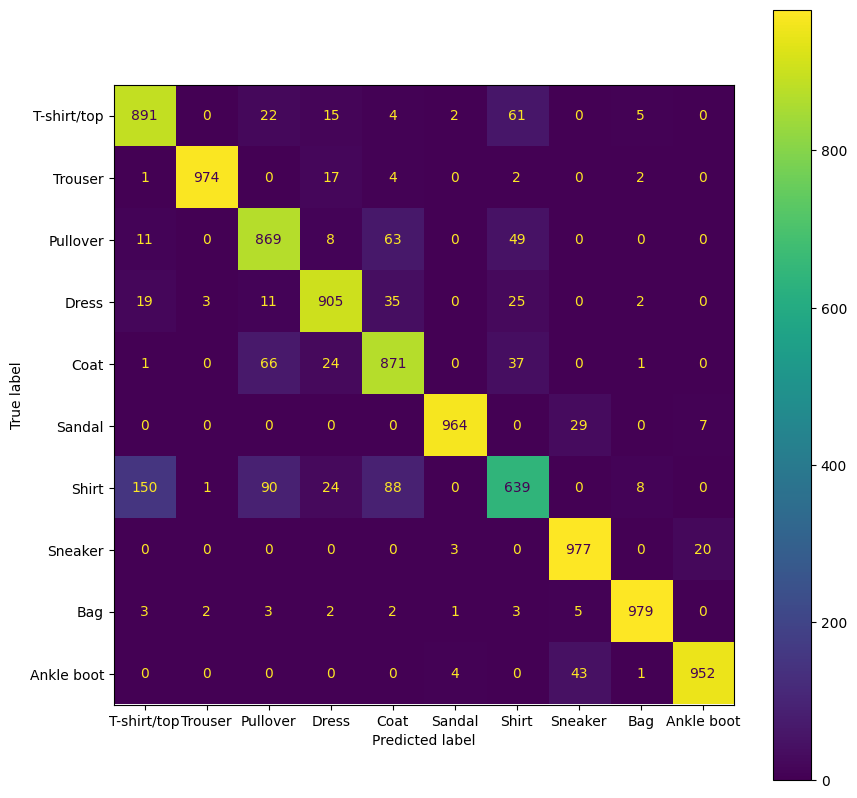

```python
from sklearn.metrics import ConfusionMatrixDisplay

fig, ax = plt.subplots(figsize=(10,10))

ConfusionMatrixDisplay.from_estimator(clf, X_test, y_test, display_labels=class_names, ax=ax)
```

## More epochs

Keras makes it easy to continue the training where we left off earlier. It saves the information needed to continue training the neural network.

When we specify `initial_epoch`, the value of `epochs` is the epoch at which training ends, rather than the number of epochs we train over.

That is, if we set `initial_epoch=3` and `epochs=4`, then we will only optimize over a single epoch.

This convention is useful if we want to keep track of how many epochs of training have been performed.

```python
model.fit(X_train, y_train,
          batch_size=256,
          epochs=8,
          verbose=1,
          validation_data=(X_valid, y_valid),
          initial_epoch=4)

score = model.evaluate(X_test, y_test)
print('Test loss:    ', score[0])
print('Test accuracy:', score[1])
```

```
215/215 ━━━━━━━━━━━━━━━━━━━━ 46s 214ms/step - accuracy: 0.9014 - loss: 0.2747 - val_accuracy: 0.9176 - val_loss: 0.2330
215/215 ━━━━━━━━━━━━━━━━━━━━ 45s 209ms/step - accuracy: 0.9059 - loss: 0.2566 - val_accuracy: 0.9170 - val_loss: 0.2272
215/215 ━━━━━━━━━━━━━━━━━━━━ 46s 214ms/step - accuracy: 0.9139 - loss: 0.2358 - val_accuracy: 0.9212 - val_loss: 0.2143
215/215 ━━━━━━━━━━━━━━━━━━━━ 44s 207ms/step - accuracy: 0.9187 - loss: 0.2201 - val_accuracy: 0.9234 - val_loss: 0.2060
313/313 ━━━━━━━━━━━━━━━━━━━━ 3s 8ms/step - accuracy: 0.9162 - loss: 0.2295
Test loss:     0.2295241504907608
Test accuracy: 0.9161999821662903
```

# Keras callbacks

Keras has a number of [callback](https://keras.io/callbacks) functions that can be used to specify actions to occur during training.

Callbacks include

- `ModelCheckpoint`, which saves the model after every epoch;
- `EarlyStopping`, which stops the training when a specified metric of quality has stopped improving;
- `ReduceLROnPlateau`, which reduces the learning rate when a specified metric of quality has stopped improving; and
- `TerminateOnNaN`, which terminates the training when a NaN is computed as the loss value.

# Looking at the neural network

We can look at the weights for layer `k` using `model.layers[k].get_weights()`.

```python
print(model.layers[1].get_weights())
```

[output not shown]

[output cut: 60 more lines]

[output not shown]

# Saving the model

We can use the model's `save` method to [save the model](https://keras.io/api/models/model_saving_apis/model_saving_and_loading/).

Saving the model saves the layout and the weights in the neural network, and also the optimizer's state so that you can continue training the model.

```python
print('saving the model...', end='')
model.save('fashion_mnist.keras')
print('done!')
```

```
saving the model...done!
```

We can load the saved model using `keras.models.load_model`.

```python
from keras.models import load_model

model2 = load_model('fashion_mnist.keras')
```

```python
del model2
```

# Data augmentation

**Data augmentation** refers to creating new training examples from our training data. This is especially useful when dealing with image data.

```python
import tensorflow as tf

print('reconstructing the model...', end='')

model2 = keras.models.Sequential()
model2.add(keras.layers.InputLayer(shape=(28,28,1)))
model2.add(keras.layers.Rescaling(scale=1.0/255.0))
model2.add(keras.layers.Conv2D(32, kernel_size=(3, 3), activation='relu'))
model2.add(keras.layers.Conv2D(64, (3, 3), activation='relu'))
model2.add(keras.layers.MaxPooling2D(pool_size=(2, 2)))
model2.add(keras.layers.Dropout(0.25))
model2.add(keras.layers.Flatten())
model2.add(keras.layers.Dense(128, activation='relu'))
#model2.add(keras.layers.Dropout(0.5))
model2.add(keras.layers.Dense(num_classes, activation='softmax'))

model2.compile(loss=keras.losses.sparse_categorical_crossentropy,
              optimizer=keras.optimizers.Adadelta(),
              metrics=['accuracy'])

print('done!')
```

```
reconstructing the model...done!
```

```python
# Try to control the randomness.
np.random.seed(42)
tf.random.set_seed(54)

datagen = keras.preprocessing.image.ImageDataGenerator(
  width_shift_range=0.1,               # randomly shift images horizontally (fraction of total width)
  height_shift_range=0.1,              # randomly shift images vertically (fraction of total height)
                                       # The remaining options are here for illustrative purposes only.
  featurewise_center=False,            # set input mean to 0 over the dataset
  samplewise_center=False,             # set each sample mean to 0
  featurewise_std_normalization=False, # divide inputs by std of the dataset
  samplewise_std_normalization=False,  # divide each input by its std
  zca_whitening=False,                 # apply ZCA whitening
  rotation_range=0,                    # randomly rotate images in the range (in degrees, 0 to 180)
  horizontal_flip=False,               # randomly flip images
  vertical_flip=False)                 # randomly flip images

# Compute quantities required for feature-wise normalization
# (std, mean, and principal components if ZCA whitening is applied).
datagen.fit(X_train)
```

```python
# Fit the model on the batches generated by datagen.flow().
model.fit(datagen.flow(X_train, y_train, batch_size=128),
                       epochs=4,
                       verbose=1,
                       validation_data=(X_valid, y_valid))

score = model.evaluate(X_test, y_test)
print('Test loss:    ', score[0])
print('Test accuracy:', score[1])
```

```
430/430 ━━━━━━━━━━━━━━━━━━━━ 48s 110ms/step - accuracy: 0.8184 - loss: 0.4913 - val_accuracy: 0.9008 - val_loss: 0.2595
430/430 ━━━━━━━━━━━━━━━━━━━━ 46s 106ms/step - accuracy: 0.8467 - loss: 0.4206 - val_accuracy: 0.9072 - val_loss: 0.2409
430/430 ━━━━━━━━━━━━━━━━━━━━ 48s 112ms/step - accuracy: 0.8584 - loss: 0.3885 - val_accuracy: 0.9108 - val_loss: 0.2463
430/430 ━━━━━━━━━━━━━━━━━━━━ 46s 107ms/step - accuracy: 0.8643 - loss: 0.3758 - val_accuracy: 0.9130 - val_loss: 0.2291
313/313 ━━━━━━━━━━━━━━━━━━━━ 3s 8ms/step - accuracy: 0.9095 - loss: 0.2487
Test loss:     0.24866387248039246
Test accuracy: 0.909500002861023
```